# Exploratory Data Analysis - Electric power consumption

Deviprasad Pandey

20 May 2018

## Background and Data

This assignment uses data from the UC Irvine Machine Learning Repository, a popular repository for machine learning datasets. In particular, we will be using the “Individual household electric power consumption Data Set”. This data set is Measurements of electric power consumption in one household with a one-minute sampling rate over a period of almost 4 years. Different electrical quantities and some sub-metering values are available. The following descriptions of the 9 variables in the dataset are taken from the UCI web site:

Date: Date in format dd/mm/yyyy

Time: time in format hh:mm:ss

Global_active_power: household global minute-averaged active power (in kilowatt)

Global_reactive_power: household global minute-averaged reactive power (in kilowatt)

Voltage: minute-averaged voltage (in volt)

Global_intensity: household global minute-averaged current intensity (in ampere)

Sub_metering_1: energy sub-metering No. 1 (in watt-hour of active energy). It corresponds to the kitchen, containing mainly a dishwasher, an oven and a microwave (hot plates are not electric but gas powered).

Sub_metering_2: energy sub-metering No. 2 (in watt-hour of active energy). It corresponds to the laundry room, containing a washing-machine, a tumble-drier, a refrigerator and a light.

Sub_metering_3: energy sub-metering No. 3 (in watt-hour of active energy). It corresponds to an electric water-heater and an air-conditioner.

## Setup

Below libraries were used in this project. One would need to install and load them in their working enviorment

```r
library(data.table)
```

## Loading the data

Once the data is downloaded from the data source, we can read the data file into data frame.

```r
path2data <- setwd(getwd())

data <- fread(file.path(path2data,"household_power_consumption.txt"),na.strings = c("NA","?", ""))
```

```
##
Read 32.8% of 2075259 rows
Read 52.5% of 2075259 rows
Read 72.3% of 2075259 rows
Read 92.0% of 2075259 rows
Read 2075259 rows and 9 (of 9) columns from 0.124 GB file in 00:00:06
```

```r
data[,Date1:= as.Date(Date,format = "%d/%m/%Y")]

dim(data)
```

```
## [1] 2075259      10
```

## subset data

```r
## Subset the data for the 2 days of Feb 2007
sub_data <- data[Date1 >= "2007-02-01" & Date1 <= "2007-02-02"]

## Combine Date and Time
sub_data$dateTime <- paste(sub_data$Date1, sub_data$Time)

## Format dateTime Column
sub_data$dateTime <- as.POSIXct(sub_data$dateTime)
```

## Plot 1

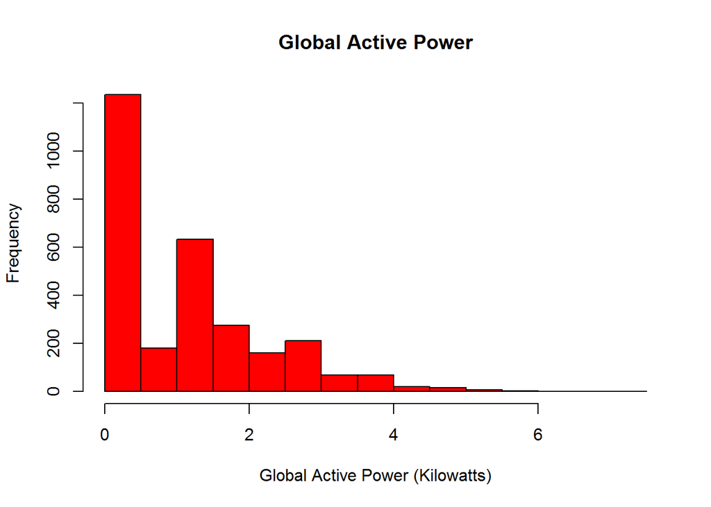

```r
hist(sub_data$Global_active_power,col = "red",xlab = "Global Active Power (Kilowatts)",main = "Global Active Power")
```

```r
## Save file and close device
#dev.copy(png,"plot1.png", width=480, height=480)
#dev.off()
```

## Plot 2

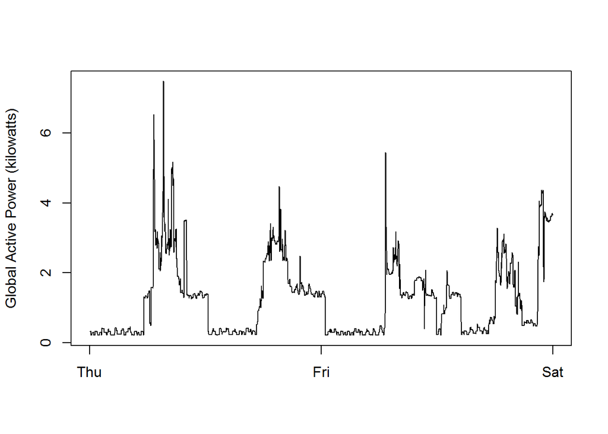

```r
plot(sub_data$Global_active_power ~ sub_data$dateTime, type="l", ylab="Global Active Power (kilowatts)", xlab="")
```

```r
#dev.copy(png,"plot2.png", width=480, height=480)
#dev.off()
```

## Plot 3

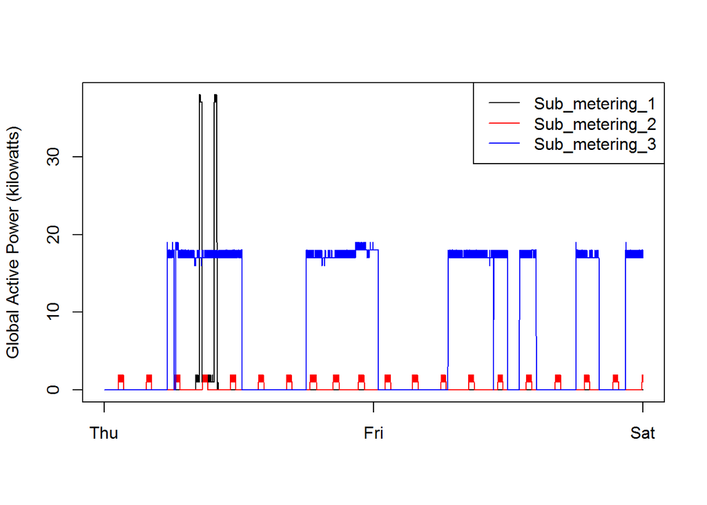

```r
## Create Plot 3
with(sub_data, {
  plot(Sub_metering_1 ~ dateTime, type="l",
       ylab="Global Active Power (kilowatts)", xlab="")
  lines(Sub_metering_2 ~ dateTime,col='Red')
  lines(Sub_metering_3 ~ dateTime,col='Blue')
})
legend("topright", col=c("black", "red", "blue"), lwd=c(1,1,1),
       c("Sub_metering_1", "Sub_metering_2", "Sub_metering_3"))
```

```r
## Saving to file
#dev.copy(png, file="plot3.png", height=480, width=480)
#dev.off()
```

## Plot 4

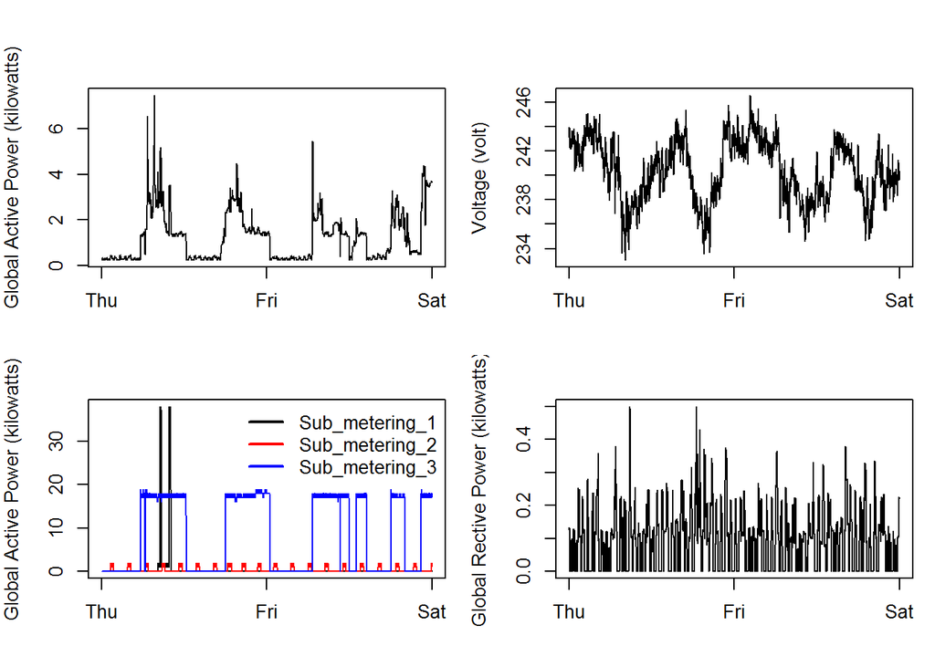

```r
## Create Plot 4
par(mfrow=c(2,2), mar=c(4,4,2,1), oma=c(0,0,2,0))
with(sub_data, {
  plot(Global_active_power~dateTime, type="l",
       ylab="Global Active Power (kilowatts)", xlab="")
  plot(Voltage~dateTime, type="l",
       ylab="Voltage (volt)", xlab="")
  plot(Sub_metering_1~dateTime, type="l",
       ylab="Global Active Power (kilowatts)", xlab="")
  lines(Sub_metering_2~dateTime,col='Red')
  lines(Sub_metering_3~dateTime,col='Blue')
  legend("topright", col=c("black", "red", "blue"), lty=1, lwd=2, bty="n",
         legend=c("Sub_metering_1", "Sub_metering_2", "Sub_metering_3"))
  plot(Global_reactive_power~dateTime, type="l",
       ylab="Global Rective Power (kilowatts)",xlab="")
})
```

```r
## Saving to file
#dev.copy(png, file="plot4.png", height=480, width=480)
#dev.off()
```